# Monte-Carlo Studies

31 October, 2019

## SCR Part 2

## SCR Part 2:

- Statistical Computing: (Re)sampling studies (4 lectures)
- Reproducibility: Dynamic Documents / Tidyverse (2 Lectures)

## About the assignment and the exam

- Midterm
- Assignment
- Next Exam

## Monte-Carlo Studies

## Outline of today

Using Monte-Carlo experiments to study a certain statistic.

Chapter 6 Book Rizzo!

Objectives:

- Get familiar with Statistical Jargon in Monte Carlo studies
- Awareness of simulation error
- A general framework for Monte Carlo studies to e.g.:
  - approximate the bias of an estimator
  - approximate the type I error and/or Power of a test

## Monte Carlo Studies

We know \(f_X\), and we need to study \(T(\mathbf{X})\).

DISTRIBUTION: \(f_X\)

DATA: \(\mathbf{X} = \{ X_1, \ldots, X_n \} \overset{\text{iid}}{\sim} f_X\)

STATISTIC: \(T(\mathbf{X})\)

## Why?

In statistics / data science:

- to investigate statistical properties (e.g. the properties of a sampling distribution);
- to evaluate the performance of statistical procedure (e.g. thesis!);
- to clarify or verify your math (e.g. see the central limit theorem at work)

## All about built-in Random Variate Generators

Functions in `R` to generate variates randomly:

- `rnorm()`: Normal distribution
- `rbinom()`: Binomial distribution
- `rt()`: t-distribution
- `runif()`: Uniform distribution
- `rchisq()`: Chi-squared distribution
- `rgamma()`: Gamma distribution
- `rexp()`: Exponential distribution

## Monte Carlo Studies: Today

We know \(f_X\), and we need to study \(T(\mathbf{X})\).

For example to estimate distributions, integrals, probabilities:

- Sampling distribution
- Bias of an estimator
- Mean Squared Error (MSE)
- Simulation Error
- Type I error
- Power

## A first example: throwing a ball

## Throwing a ball

Suppose you ask me to throw a ball 50 meters, how far will my throw on average be?

How would you answer this question?

## Exercises part 1

## Throwing a ball: summary

Which answer did you prefer, the analytical one or the monte carlo one?

The answer you got differed from the answer of your neighbour, why?

The exercise was about different sample and sampling distributions, which ones?

## Sampling Distribution

## Sampling distribution

DATA: \(\mathbf{X} = \{ X_1, \ldots, X_n \} \overset{\text{iid}}{\sim} f_X\)

STATISTIC: \(T(\mathbf{X})\)

The distribution of \(T\) is called sampling distribution

## Theoretical Sampling Distribution

Towards a theoretical sampling distribution:

If \(\mathbf{X} = X_1, \ldots, X_n \stackrel{i.i.d.}{\sim} N(0, \sigma^2)\)

with sample variance \(S^2 = \frac{1}{n - 1} \sum^{n}_{i = 1} (X_i - \overline{X})^2\),

then

\[T(\mathbf{X}) = \frac{\overline{X}\sqrt{n}}{S} ~ \sim t_{n - 1},\]

where \(t_{n - 1}\) is a theoretical \(t\)-distribution.

## Estimation of a Sampling distribution

For \(b = 1,\ldots,B\)

- generate replicate \(b\) for data \(\mathbf{X}\), called \(\mathbf{X}^{b}\)
- compute \(T^b =T(\mathbf{X}^{b})\)

Make a plot (histogram, density, ecdf) of \(T^1,\ldots,T^B\).

## Live coding: monte carlo sampling distribution

```r
set.seed(20171102)
N <- 25
B <- 10000

T_function <- function(X){
  n <- length(X)
  return(mean(X) * sqrt(n) / sd(X))
}

T_replicates <- numeric(B)
for (b in 1:B){
  X <- rnorm(N)
  T_replicates[b] <- T_function(X)
}
```

## Live coding: monte carlo sampling distribution

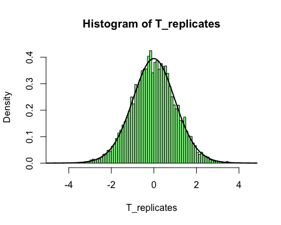

```r
hist(T_replicates, freq=F, breaks="FD", col='lightgreen')
x_seq <- seq(-10, 10, by=0.01)
lines(x_seq, dt(x_seq, df=N-1), lwd=2)
```

## Standard Error

## Standard Error

DATA: \(\mathbf{X} = \{ X_1, \ldots, X_n \} \overset{\text{iid}}{\sim} f_X\)

STATISTIC: \(T(\mathbf{X})\)

The standard deviation in the sampling distribution of \(T\) is called the standard error.

## Example: Standard Error

If \(\mathbf{X} = X_1, \ldots, X_n \overset{\text{iid}}{\sim} N(0, \sigma^2)\)

and \(T(\mathbf{X}) = \overline{X}\),

then standard error is \[\sigma_{\overline{X}} = \frac{\sigma}{\sqrt{n}}\]

(Also known as S.E., SE)

## Example: monte carlo Standard Error

DATA \(\mathbf{X} = X_1, \ldots, X_n \overset{\text{iid}}{\sim} N(0, \sigma^2)\)

STATISTIC \(T = T(\mathbf{X})\)

DETERMINATION OF STANDARD ERROR BY SIMULATION:

For \(b = 1,\ldots,B\)

- generate independent replicate \(\mathbf{X}^b\)
- compute \(T^b =T(\mathbf{X}^b)\)

Compute root of variance \(T^1, \ldots, T^B\), i.e.

\[ \widehat{\text{SE}_T} = \sqrt{ \frac{1}{B} \sum^B_{b = 1} (T^b - \overline{T})^2}, \qquad \qquad \textrm{where } \overline{T} = \frac{1}{B} \sum^B_{b = 1} T^b \]

## Live coding: standard error, monte carlo in `R`

```r
N <- 100
B <- 1000

sample <- rnorm(N)
mean(sample)
```

```
## [1] -0.1167305
```

```r
#theoretical:
1/sqrt(N)
```

```
## [1] 0.1
```

```r
#'empirical':
sd(replicate(B, mean(rnorm(N))))
```

```
## [1] 0.101359
```

## Exercises part 2

## Bias and MSE of estimators

## Bias of estimators

ESTIMATOR \(T = T(\mathbf{X})\) OF QUANTITY \(\theta\)

BIAS of \(T\): \(\textrm{E}\left[T\right] - \theta\)

EXAMPLE OF THEORETICAL BIAS:

- If \(X_1, \ldots, X_n \stackrel{i.i.d.}{\sim} N(0,\sigma^2)\), then bias of \(\bar{X}\) for \(\theta\) is 0.

## Bias of estimators

ESTIMATOR \(T = T(\mathbf{X})\) OF QUANTITY \(\theta\)

BIAS of \(T\): \(\textrm{E}\left[T\right] - \theta\)

MONTE CARLO EXAMPLE OF THEORETICAL BIAS:

For \(b = 1,\ldots,B\)

- generate independent replicate \(\mathb{X}^b\)
- compute \(T^b =T(\mathbf{X}^b)\)

Compute:  
\[ \widehat{(\textrm{E}\left[T\right] - \theta)} = \frac{1}{B} \sum^B_{b = 1} T^b - \theta \]

## MSE: Mean Square Error

MSE of an estimator is the sum of its Bias\(^2\) and its Variance

Recall throwing a ball: the mean throw was already off.

So the average squared error (from target to throwing distance) will be off by bias^2, plus the variance around the throw

## MSE: Mean Square Error

ESTIMATOR \(T = T(\mathbf{X})\) OF QUANTITY \(\theta\)

The *mean square error* (MSE) of \(T\) is \(\textrm{E}\left[(T - \theta)^2\right]\).

## MSE: decomposed

MSE:  
\(\textrm{E}[(T - \theta)^2] = \textrm{E}[T^2] + \theta^2 - 2\textrm{E}[T]\theta\)

Squared bias:  
\((\textrm{E}[(T - \theta)])^2 = (\textrm{E}[T])^2 + \theta^2 - 2\textrm{E}[T]\theta\)

Variance:  
\(\textrm{E}[(T - \textrm{E}[T])^2 = \textrm{E}[T^2] - ( \textrm{E}[T])^2\)

MSE = Squared bias + Variance

## Verify Theoretical MSE

If \(\mathbf{X} = X_1, \ldots, X_n \overset{\text{iid}}{\sim} N(\theta, \sigma^2)\), then MSE of \(\overline{X}\) for \(\theta\) is \(\sigma^2/n\).

USING MONTE CARLO APPROXIMATION:

For \(b = 1,\ldots,B\)

- generate independent replicate \(\mathbf{X}^b\)
- compute \(T^b =T(X^b)\)

Compute \[ \widehat{MSE} = \frac{1}{B} \sum^B_{b = 1} (T^b - \theta)^2 \]

## Exercises part 3

## Levels of sampling.

Be very mindful of the level at which you need extra repetitions:

- If you want a better estimate of the median per sample, increase \(n\)
- If you want a better estimate of the mean of the median, increase \(B\) (to decrease simulation error)
- If you want a better estimate of the standard error of the sampling distribution of the mean of the median, repeat the expirment with \(B\) replicates \(M\) time, and check out the average of the \(M\) standard errors…

## Simulation error

By making \(B\) larger, the simulation error can be made arbitrarily small. \(B = 10,000\) is desirable, but \(B = 1,000\) is typical, and only \(B = 100\) may be feasible.

If \(\textrm{E}\left[T\right]\) is estimated by \(\overline{T}\) for i.i.d. \(T^1,\ldots,T^B,\) then CLT kicks in (again):

\[ \bar{T}_B - \textrm{E}\left[T\right] \sim N(0, \sigma_T^2/B). \]

Why would CLT kick in?

Thus the standard error of simulation, \(\sqrt{\textrm{var}_T/ B},\) and can be estimated by

\[ \sqrt{B^{-1} \sum^B_{b=1} (T^b - \overline{T})^2/B } \]

## Standard error of Simulation

By making \(B\) larger, the simulation error can be made arbitrarily small. \(B = 10,000\) is desirable, but \(B = 1,000\) is typical, and only \(B = 100\) may be feasible.

EXAMPLE:

If the MSE, \(\textrm{E}\left[(T - \theta)^2\right]\), is estimated by \(\widehat{MSE} = B^{-1} \sum^B_{b = 1}(T^b - \theta)^2\), then the simulation error can be estimated by \[ \widehat{\text{SE}_\text{sim}} = \frac{1}{B}\sqrt{\sum^B_{b=1}\left[ (T^b - \theta)^2 - \widehat{MSE} \right]^2} \]

## Size / Type 1 error

## Size / Type 1 error

STATISTIC \(T = T(\mathbf{X})\)

\(H_0 :=\) null hyptohesis

Reject \(H_0\) if \(T \in K_0\).

\(K_0: =\) domain of values for \(T\) which are unlikely under \(H_0\).

\(\alpha = P_{H_0}(T \in K_0)\).

## Compute size or Type 1 error by Simulation.

Reject \(H_0\) if \(T \in K_0\).

\(K: =\) domain of values for \(T\) which are unlikely under \(H_0\).

What is \(\alpha = P_{H_0}(T \in K)\)?

For \(b = 1,\ldots,B\)

- generate independent replicate \(\mathbf{X}^b\) using the null distribution
- compute \(T^b =T(X^b)\)
- compute

\[ \hat{\alpha} = \frac{1}{B} \sum^B_{b = 1} 1_{T^b \in K} = \textrm{fraction rejections}, \]

where \(1_{T^b \in K} = 1\) if \(T^b \in K\), and \(0\) otherwise.

## Live coding: Size / Type 1 error in `R`

Suppose we define the following. We know that the average of a sample is distributed according to a normal distribution, with standard deviation \(1\). The *null hypothesis* is that the average of this distribution is \(0\). The test, for \(N=10\) is: we reject the null hypothesis that the mean of the population is \(0\) if the test statistic is smaller than -1, or larger than 1.

```r
set.seed(21135)
N <- 10
B <- 1000

# simulate from null distribution.
z <- replicate(B, rnorm(N))

t_in_k <- (z < -1) + (z > 1)
mean(t_in_k)
```

```
## [1] 0.3154
```

With this test, we falsely reject the null hypothesis for 31.54% in samples of size \(N=10\).

## Power

## Power

STATISTIC \(T = T(\mathbf{X})\)

\(H_1 :=\) Alternative hypothesis

STATISTIC \(T = T(\mathbf{X})\)

We reject \(H_0\) if it falls in critical region \(K_0\)

The power is \(P_{H_1}(T \in K_0)\) viewed as function of the parameter space in \(H_1\).

## Power

The power is \(P_{\theta_1}(T \in K_0)\) viewed as function of the alternative \(\theta_1\) from \(H_1\).

DETERMINATION OF POWER BY SIMULATION

For \(b = 1,\ldots,B\)

- generate independent replicate \(\mathbf{X}^b\) while *using alternative* \(\theta_1\)
- compute \(T^b =T(\mathbf{X}^b)\)

Compute

\[ \frac{1}{B}\sum^B_{b = 1} 1_{T^b \in K_0} \]

Repeat for all alternatives.

## When you do **Simulations / Monte Carlo Experiments**

Note to self:

- Good documentation is essential!
- Write separate programs for each case or keep a precise record
- Think about which output you need to save, and do that in a structured way
- Make programs ‘re-startable’ in case of emergency..
- Divide the work over more computers.

## Recap of today

- Statistical distribution functions
- Sampling distribution
- Estimators: Bias and MSE
- Standard Error of Simulation
- Type 1 error
- Power

## Work on the exercises / self-study